# Assignment 1 Python for DS

### 10. Plot the distribution of Overall rating for all the players and write your findings.

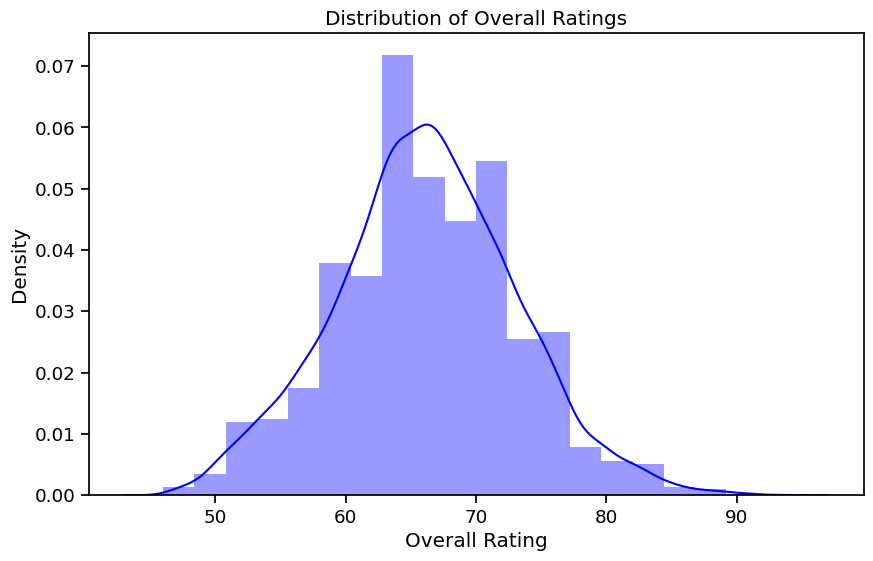

```python
# Distribution of Overall rating for all the players using displot
plt.figure(figsize=(10, 6))
sns.distplot(fifa_df['Overall'], bins=20, color='blue', kde=True)
plt.title('Distribution of Overall Ratings')
plt.xlabel('Overall Rating')
plt.ylabel('Density')
plt.grid(False)
plt.show()
```

FINDINGS-

1. The overall ratings of players range from approximately 46 to 94.
2. The ratings are clustered primarily between 60 and 70, indicating that a significant number of players fall within this range.
3. The range of ratings among players in the dataset is quite broad, with the lowest overall rating being 46, and the highest being 94.
4. The most common rating among the players in the dataset appears to be around 66, as evidenced by the peak.
5. On the higher end of the rating scale, there might be some data points that are outliers.
6. The distribution of the data shows a long tail that goes beyond the bulk of the dataset, indicating the presence of some data points with extremely high ratings compared to the majority of the data.
7. This plot identifies the central tendency of player ratings, the range of ratings, and the potential presence of outliers.

### 11. Retrieve the names of top20 players based on the Overall rating.

```python
# Sorting in descending order Name and their overall rating
Top_20_names = fifa_df[['Name','Overall']].sort_values(by = 'Overall', ascending = False).head(20).reset_index()

# Top 20 players with their overall rating
Top_20_names
```

|  | index | Name | Overall |
| --- | --- | --- | --- |
| 0 | 0 | L. Messi | 94 |
| 1 | 1 | Cristiano Ronaldo | 94 |
| 2 | 2 | Neymar Jr | 92 |
| 3 | 3 | De Gea | 91 |
| 4 | 4 | K. De Bruyne | 91 |
| 5 | 5 | E. Hazard | 91 |
| 6 | 6 | L. Modrić | 91 |
| 7 | 7 | L. Suárez | 91 |
| 8 | 8 | Sergio Ramos | 91 |
| 9 | 12 | D. Godín | 90 |
| 10 | 13 | David Silva | 90 |
| 11 | 9 | J. Oblak | 90 |
| 12 | 11 | T. Kroos | 90 |
| 13 | 10 | R. Lewandowski | 90 |
| 14 | 20 | Sergio Busquets | 89 |
| 15 | 24 | G. Chiellini | 89 |
| 16 | 23 | S. Agüero | 89 |
| 17 | 22 | M. Neuer | 89 |
| 18 | 21 | E. Cavani | 89 |
| 19 | 16 | H. Kane | 89 |

### 12. Generate a dataframe which should include all the information of the Top 20 players based on the Overall rating.

```python
# Filter player data file by matching 'Name' and 'Overall' columns with those in Top_20_names DataFrame.
fifa_df_top20 = fifa_df[(fifa_df['Name'].isin(Top_20_names['Name'])) &
                        (fifa_df['Overall'].isin(Top_20_names['Overall']))].reset_index(drop=True)

# Required DataFrame
fifa_df_top20
```

|  | ID | Name | Age | Nationality | Overall | Potential | Club | Value | Wage | Preferred Foot | International Reputation | Weak Foot | Skill Moves | Work Rate | Body Type | Position | Joined | Contract Valid Until | Height (inch) | Weight (lbs) | Crossing | Finishing | HeadingAccuracy | ShortPassing | Volleys | Dribbling | Curve | FKAccuracy | LongPassing | … |
| --- | --- | --- | --- | --- | --- | --- | --- | --- | --- | --- | --- | --- | --- | --- | --- | --- | --- | --- | --- | --- | --- | --- | --- | --- | --- | --- | --- | --- | --- | --- |
| 0 | 158023 | L. Messi | 31 | Argentina | 94 | 94 | FC Barcelona | 110500000.0 | 565000.0 | Left | 5.0 | 4.0 | 4.0 | Medium/ Medium | Messi | RF | 2004 | 2021-01-01 | 5.70 | 159.0 | 84.0 | 95.0 | 70.0 | 90.0 | 86.0 | 97.0 | 93.0 | 94.0 | 87.0 | … |
| 1 | 20801 | Cristiano Ronaldo | 33 | Portugal | 94 | 94 | Juventus | 77000000.0 | 405000.0 | Right | 5.0 | 4.0 | 5.0 | High/ Low | C. Ronaldo | ST | 2018 | 2022-01-01 | 6.20 | 183.0 | 84.0 | 94.0 | 89.0 | 81.0 | 87.0 | 88.0 | 81.0 | 76.0 | 77.0 | … |
| 2 | 190871 | Neymar Jr | 26 | Brazil | 92 | 93 | Paris Saint-Germain | 118500000.0 | 290000.0 | Right | 5.0 | 5.0 | 5.0 | High/ Medium | Neymar | LW | 2017 | 2022-01-01 | 5.90 | 150.0 | 79.0 | 87.0 | 62.0 | 84.0 | 84.0 | 96.0 | 88.0 | 87.0 | 78.0 | … |
| 3 | 193080 | De Gea | 27 | Spain | 91 | 93 | Manchester United | 72000000.0 | 260000.0 | Right | 4.0 | 3.0 | 1.0 | Medium/ Medium | Lean | GK | 2011 | 2020-01-01 | 6.40 | 168.0 | 17.0 | 13.0 | 21.0 | 50.0 | 13.0 | 18.0 | 21.0 | 19.0 | 51.0 | … |
| 4 | 192985 | K. De Bruyne | 27 | Belgium | 91 | 92 | Manchester City | 102000000.0 | 355000.0 | Right | 4.0 | 5.0 | 4.0 | High/ High | Normal | RCM | 2015 | 2023-01-01 | 5.11 | 154.0 | 93.0 | 82.0 | 55.0 | 92.0 | 82.0 | 86.0 | 85.0 | 83.0 | 91.0 | … |
| 5 | 183277 | E. Hazard | 27 | Belgium | 91 | 91 | Chelsea | 93000000.0 | 340000.0 | Right | 4.0 | 4.0 | 4.0 | High/ Medium | Normal | LF | 2012 | 2020-01-01 | 5.80 | 163.0 | 81.0 | 84.0 | 61.0 | 89.0 | 80.0 | 95.0 | 83.0 | 79.0 | 83.0 | … |
| 6 | 177003 | L. Modrić | 32 | Croatia | 91 | 91 | Real Madrid | 67000000.0 | 420000.0 | Right | 4.0 | 4.0 | 4.0 | High/ High | Lean | RCM | 2012 | 2020-01-01 | 5.80 | 146.0 | 86.0 | 72.0 | 55.0 | 93.0 | 76.0 | 90.0 | 85.0 | 78.0 | 88.0 | … |
| 7 | 176580 | L. Suárez | 31 | Uruguay | 91 | 91 | FC Barcelona | 80000000.0 | 455000.0 | Right | 5.0 | 4.0 | 3.0 | High/ Medium | Normal | RS | 2014 | 2021-01-01 | 6.00 | 190.0 | 77.0 | 93.0 | 77.0 | 82.0 | 88.0 | 87.0 | 86.0 | 84.0 | 64.0 | … |
| 8 | 155862 | Sergio Ramos | 32 | Spain | 91 | 91 | Real Madrid | 51000000.0 | 380000.0 | Right | 4.0 | 3.0 | 3.0 | High/ Medium | Normal | RCB | 2005 | 2020-01-01 | 6.00 | 181.0 | 66.0 | 60.0 | 91.0 | 78.0 | 66.0 | 63.0 | 74.0 | 72.0 | 77.0 | … |
| 9 | 200389 | J. Oblak | 25 | Slovenia | 90 | 93 | Atlético Madrid | 68000000.0 | 94000.0 | Right | 3.0 | 3.0 | 1.0 | Medium/ Medium | Normal | GK | 2014 | 2021-01-01 | 6.20 | 192.0 | 13.0 | 11.0 | 15.0 | 29.0 | 13.0 | 12.0 | 13.0 | 14.0 | 26.0 | … |
| 10 | 188545 | R. Lewandowski | 29 | Poland | 90 | 90 | FC Bayern München | 77000000.0 | 205000.0 | Right | 4.0 | 4.0 | 4.0 | High/ Medium | Normal | ST | 2014 | 2021-01-01 | 6.00 | 176.0 | 62.0 | 91.0 | 85.0 | 83.0 | 89.0 | 85.0 | 77.0 | 86.0 | 65.0 | … |
| 11 | 182521 | T. Kroos | 28 | Germany | 90 | 90 | Real Madrid | 76500000.0 | 355000.0 | Right | 4.0 | 5.0 | 3.0 | Medium/ Medium | Normal | LCM | 2014 | 2022-01-01 | 6.00 | 168.0 | 88.0 | 76.0 | 54.0 | 92.0 | 82.0 | 81.0 | 86.0 | 84.0 | 93.0 | … |
| 12 | 182493 | D. Godín | 32 | Uruguay | 90 | 90 | Atlético Madrid | 44000000.0 | 125000.0 | Right | 3.0 | 3.0 | 2.0 | Medium/ High | Lean | CB | 2010 | 2019-01-01 | 6.20 | 172.0 | 55.0 | 42.0 | 92.0 | 79.0 | 47.0 | 53.0 | 49.0 | 51.0 | 70.0 | … |
| 13 | 168542 | David Silva | 32 | Spain | 90 | 90 | Manchester City | 60000000.0 | 285000.0 | Left | 4.0 | 2.0 | 4.0 | High/ Medium | Normal | LCM | 2010 | 2020-01-01 | 5.80 | 148.0 | 84.0 | 76.0 | 54.0 | 93.0 | 82.0 | 89.0 | 82.0 | 77.0 | 87.0 | … |
| 14 | 202126 | H. Kane | 24 | England | 89 | 91 | Tottenham Hotspur | 83500000.0 | 205000.0 | Right | 3.0 | 4.0 | 3.0 | High/ High | Normal | ST | 2010 | 2024-01-01 | 6.20 | 196.0 | 75.0 | 94.0 | 85.0 | 80.0 | 84.0 | 80.0 | 78.0 | 68.0 | 82.0 | … |
| 15 | 189511 | Sergio Busquets | 29 | Spain | 89 | 89 | FC Barcelona | 51500000.0 | 315000.0 | Right | 4.0 | 3.0 | 3.0 | Medium/ Medium | Lean | CDM | 2008 | 2023-01-01 | 6.20 | 168.0 | 62.0 | 67.0 | 68.0 | 89.0 | 44.0 | 80.0 | 66.0 | 68.0 | 82.0 | … |
| 16 | 179813 | E. Cavani | 31 | Uruguay | 89 | 89 | Paris Saint-Germain | 60000000.0 | 200000.0 | Right | 4.0 | 4.0 | 3.0 | High/ High | Lean | LS | 2013 | 2020-01-01 | 6.10 | 170.0 | 70.0 | 89.0 | 89.0 | 78.0 | 90.0 | 80.0 | 77.0 | 76.0 | 52.0 | … |
| 17 | 167495 | M. Neuer | 32 | Germany | 89 | 89 | FC Bayern München | 38000000.0 | 130000.0 | Right | 5.0 | 4.0 | 1.0 | Medium/ Medium | Normal | GK | 2011 | 2021-01-01 | 6.40 | 203.0 | 15.0 | 13.0 | 25.0 | 55.0 | 11.0 | 30.0 | 14.0 | 11.0 | 59.0 | … |
| 18 | 153079 | S. Agüero | 30 | Argentina | 89 | 89 | Manchester City | 64500000.0 | 300000.0 | Right | 4.0 | 4.0 | 4.0 | High/ Medium | Stocky | ST | 2011 | 2021-01-01 | 5.80 | 154.0 | 70.0 | 93.0 | 77.0 | 81.0 | 85.0 | 89.0 | 82.0 | 73.0 | 64.0 | … |
| 19 | 138956 | G. Chiellini | 33 | Italy | 89 | 89 | Juventus | 27000000.0 | 215000.0 | Left | 4.0 | 3.0 | 2.0 | Medium/ High | Normal | LCB | 2005 | 2020-01-01 | 6.20 | 187.0 | 58.0 | 33.0 | 83.0 | 59.0 | 45.0 | 58.0 | 60.0 | 31.0 | 59.0 | … |

### 13. What is the average "Age" and "Wage" of these top 20 players?

```python
# Average age of the top 20 players
average_age = fifa_df_top20['Age'].mean()

# Average wage of the top 20 players
average_wage = fifa_df_top20['Wage'].mean()

print("The average 'age' of top 20 players is", average_age, "year old")
print("The average 'wage' of top 20 players is €" + str(average_wage))
```

```
The average 'age' of top 20 players is 29.55 year old
The average 'wage' of top 20 players is €294950.0
```

### 14. Among the top 20 players based on the Overall rating, which player has the highest wage? Display the name of the player with his wage.

```python
# Filter the top 20 players in fifa_df_top20 from Q.11 by the maximum wage and select only 'Name' and 'Wage' columns to display
print("Player name with his wage:")
fifa_df_top20[fifa_df_top20['Wage']==fifa_df_top20['Wage'].max()][['Name','Wage']]
```

```
Player name with his wage:
```

|  | Name | Wage |
| --- | --- | --- |
| 0 | L. Messi | 565000.0 |

### 15. Generate a dataframe which should include the "Player name", "Club Name", "Wage", and 'Overall rating'.

```python
# Generating DataFrame according to requirement
selected_columns = ['Name', 'Club', 'Wage', 'Overall']
players_club_data = fifa_df[selected_columns]
# Few entries from generated DataFrame
players_club_data.head(5)
```

|  | Name | Club | Wage | Overall |
| --- | --- | --- | --- | --- |
| 0 | L. Messi | FC Barcelona | 565000.0 | 94 |
| 1 | Cristiano Ronaldo | Juventus | 405000.0 | 94 |
| 2 | Neymar Jr | Paris Saint-Germain | 290000.0 | 92 |
| 3 | De Gea | Manchester United | 260000.0 | 91 |
| 4 | K. De Bruyne | Manchester City | 355000.0 | 91 |

### 15.1) Find the average Overall rating for each club.

```python
# Average Overall rating for each club
average_overall_ratings = players_club_data.groupby('Club')['Overall'].mean().reset_index()
average_overall_ratings[['Club', 'Overall']]
```

|  | Club | Overall |
| --- | --- | --- |
| 0 | SSV Jahn Regensburg | 65.760000 |
| 1 | 1. FC Heidenheim 1846 | 65.750000 |
| 2 | 1. FC Kaiserslautern | 63.384615 |
| 3 | 1. FC Köln | 70.785714 |
| 4 | 1. FC Magdeburg | 65.791667 |
| ... | ... | ... |
| 646 | Zagłębie Sosnowiec | 60.625000 |
| 647 | Çaykur Rizespor | 66.666667 |
| 648 | Örebro SK | 60.346154 |
| 649 | Östersunds FK | 63.450000 |
| 650 | Śląsk Wrocław | 62.208333 |

651 rows × 2 columns

### 15.2) Display the average overall rating of Top10 Clubs using a plot

```python
# Sort DataFrame in descending order of 'Overall', find highest rated clubs
# Top 10 clubs with the highest average overall ratings
top10_clubs = average_overall_ratings.sort_values(by='Overall', ascending=False).head(10)

# Top 10 clubs and their average overall ratings
top10_clubs
```

|  | Club | Overall |
| --- | --- | --- |
| 326 | Juventus | 82.280000 |
| 398 | Napoli | 80.041667 |
| 315 | Inter | 79.619048 |
| 470 | Real Madrid | 78.242424 |
| 212 | FC Barcelona | 78.030303 |
| 382 | Milan | 77.541667 |
| 435 | Paris Saint-Germain | 77.433333 |
| 482 | Roma | 77.400000 |
| 375 | Manchester United | 77.242424 |
| 504 | SL Benfica | 77.074074 |

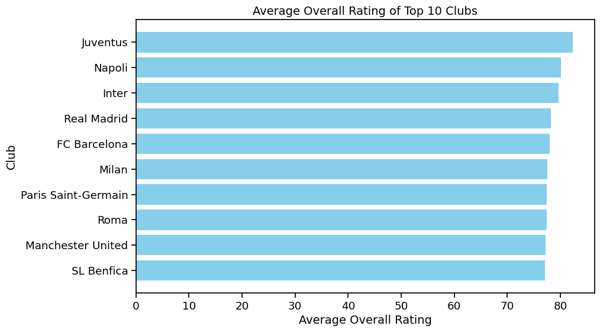

```python
# Horizontal bar plot to show the average overall rating of the top 10 clubs
plt.figure(figsize=(10, 6))
plt.barh(top10_clubs['Club'], top10_clubs['Overall'], color='skyblue')
plt.xlabel('Average Overall Rating', fontsize=14)
plt.ylabel('Club', fontsize=14)
plt.title('Average Overall Rating of Top 10 Clubs', fontsize=14)

# On y-axis plotting names of highest-rated clubs
plt.gca().invert_yaxis()
```

### 16. What is the relationship between age and individual potential of the player? Visualize the relationship with appropriate plot and Comment on the same.

```python
corr_AP = fifa_df[['Age', 'Potential']].corr()
corr_AP
```

|  | Age | Potential |
| --- | --- | --- |
| Age | 1.000000 | -0.239022 |
| Potential | -0.239022 | 1.000000 |

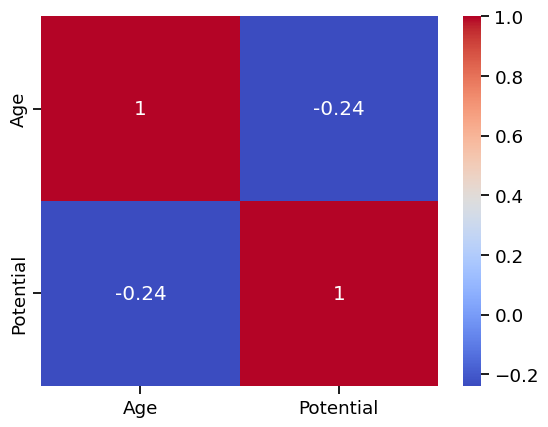

```python
sns.heatmap(corr_AP, annot=True, cmap='coolwarm')
```

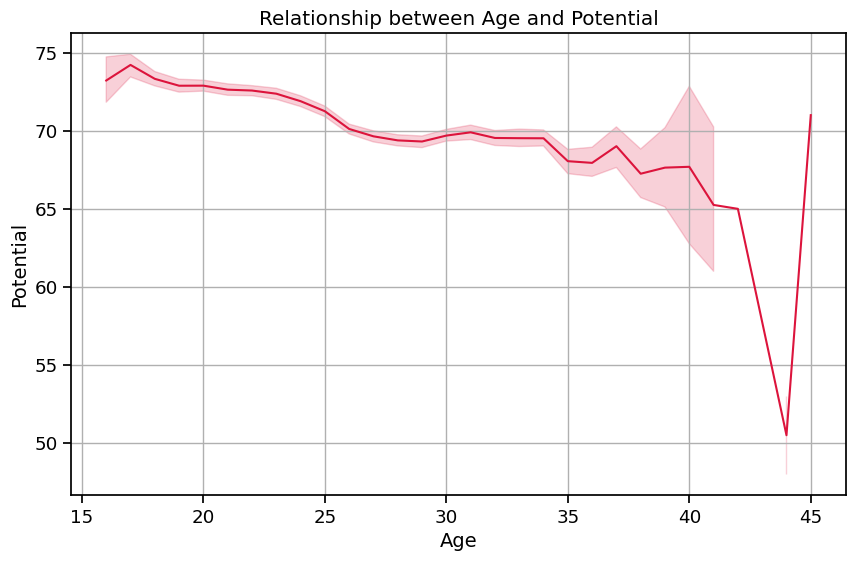

```python
# Line plot to visualize the relationship between age and potential
plt.figure(figsize=(10, 6))
sns.lineplot(x='Age', y='Potential', data=fifa_df, color='Crimson')
plt.title('Relationship between Age and Potential')
plt.xlabel('Age', fontsize=14)
plt.ylabel('Potential', fontsize=14)
plt.grid(True)
plt.show()
```

Comment:

1. There is inverse proportionality between age and potential and -0.24 is the correlation coefficient.
2. (-0.24) a weak negative linear relationship means with the increasing age their potential decreases , it is also important to note that the relationship is not much strong. So there can be many other factors responsible to decrease in potential
3. According to the seaborn line plot, it appears that players tend to achieve their maximum potential at around the age of 17 on average.
4. Beyond that, their potential gradually decreases and reaches a relatively stable level until approximately the age of 35.
5. However, after the age of 35, there seems to be a noticeable decline in the players' potential.
6. Although as said ,there can be other factors responsible for decrease in players potential but here age factor suggests younger players are full of potential than the older ones

### 17. Which features directly contribute to the wages of the players? Support your answer with a plot and a metric.

```python
# Selecting relevant features
relevant_features = ['Potential', 'Overall', 'Value', 'International Reputation', 'Release Clause']

# Calculate correlation coefficients
corr_matrix = fifa_df[relevant_features + ['Wage']].corr()

# Select correlation of 'Wage' with relevant features
wage_corr = corr_matrix[['Wage']].sort_values(by='Wage', ascending=False)

# Displaying correlation coefficients
print("Correlation coefficients of relevant features with player wages:")
print(wage_corr)
```

```
Correlation coefficients of relevant features with player wages:
                              Wage
Wage                      1.000000
Value                     0.861520
Release Clause            0.855917
International Reputation  0.677072
Overall                   0.573730
Potential                 0.490318
```

This indicates a positive correlation between player wages and these features. Players with higher Value, Release Clause, International Reputation, Overall ratings, and Potentials tend to command higher wages. Among these features, Value and Release Clause show the strongest correlation with Wage.

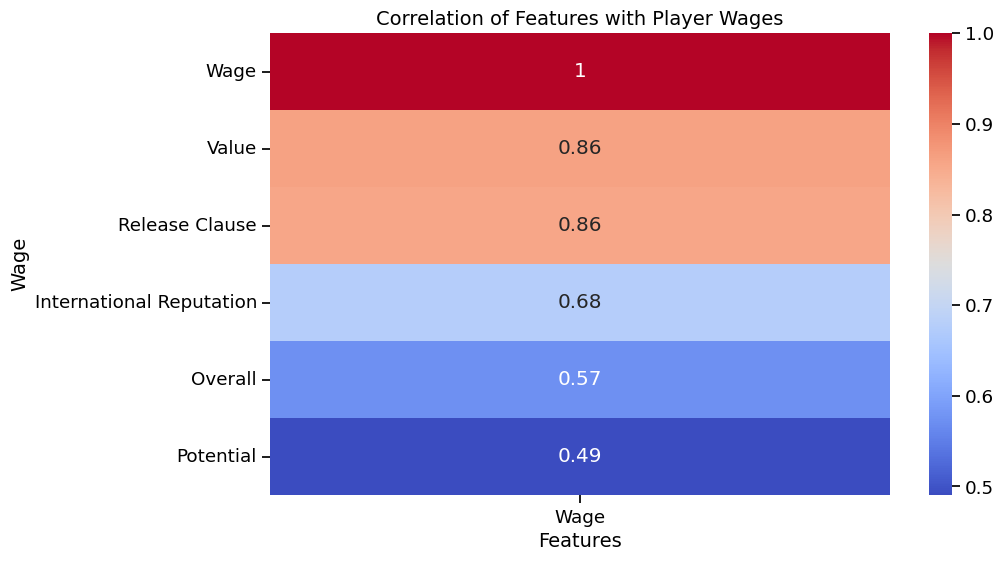

```python
# Heatmap - correlation matrix
plt.figure(figsize=(10, 6))
sns.heatmap(wage_corr, annot=True, cmap='coolwarm')
plt.title('Correlation of Features with Player Wages', fontsize=14)
plt.xlabel('Features', fontsize=14)
plt.ylabel('Wage', fontsize=14)
plt.show()
```

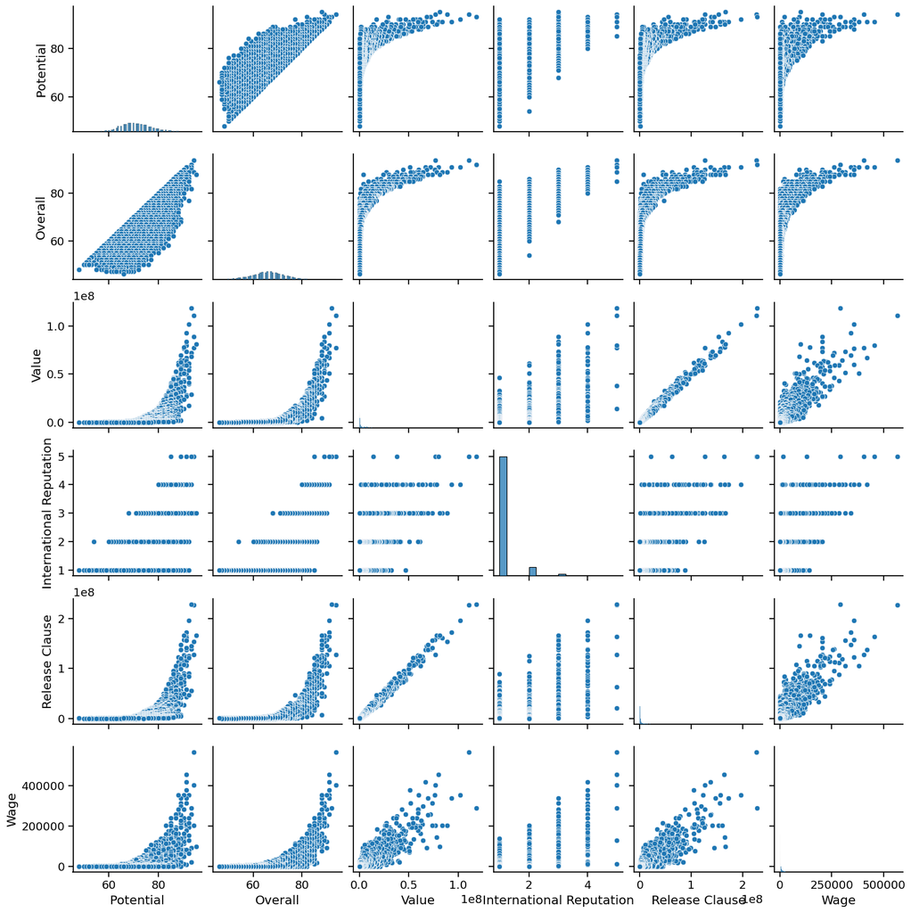

```python
# Pairplot for studying correlation
sns.set_context("notebook", font_scale=1.2)
sns.pairplot(fifa_df[relevant_features + ['Wage']])
plt.show()
```

### 18. Find the position in the pitch where the maximum number of players play and the position where the minimum number of players play? Display it using a plot.

```python
# Position with maximum number of players
max_position_info = fifa_df['Position'].value_counts().idxmax()
max_position_count = fifa_df['Position'].value_counts().max()
print(f"Position with maximum number of players: {max_position_info}, No. of Players: {max_position_count}")
```

```
Position with maximum number of players: ST, No. of Players: 1924
```

```python
# Position with minimum number of players
min_position_info = fifa_df['Position'].value_counts().idxmin()
min_position_count = fifa_df['Position'].value_counts().min()
print(f"Position with minimum number of players: {min_position_info}, No. of Players: {min_position_count}")
```

```
Position with minimum number of players: RF, No. of Players: 13
```

```python
min_position = fifa_df['Position'].value_counts().sort_values(ascending=True).head(1)
```

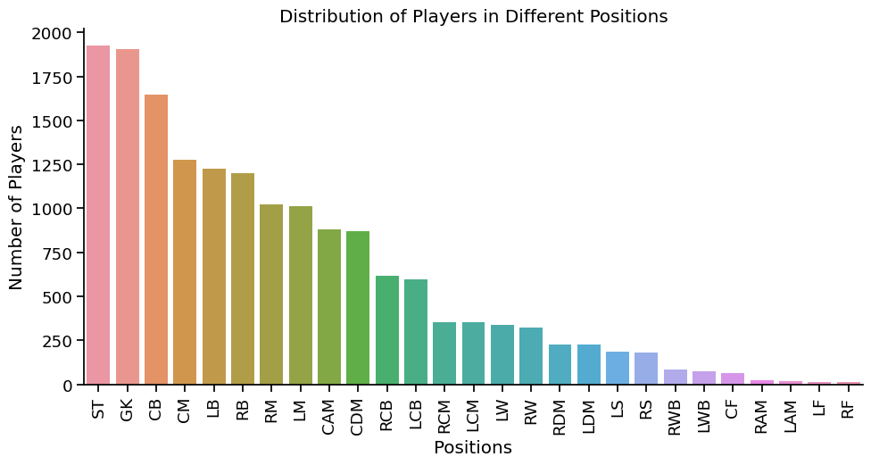

```python
# Creating a categorical plot (catplot) to visualize the distribution of player positions
sns.catplot(data=fifa_df, x="Position", kind="count", aspect=2, order=fifa_df['Position'].value_counts().index)

# Adding labels and title
plt.xlabel("Positions")
plt.ylabel("Number of Players")
plt.title("Distribution of Players in Different Positions")
plt.xticks(rotation = 90)
plt.show()
```

### 19. How many players are from the club 'Juventus' and the wage is greater than 200K? Display all the information of such players.

```python
# Seperating Juventus players with >200K wage
juventus_high_wage = fifa_df[(fifa_df['Club'] == 'Juventus') & (fifa_df['Wage'] > 200000)].reset_index(drop=True)

# List
juventus_high_wage
```

|  | ID | Name | Age | Nationality | Overall | Potential | Club | Value | Wage | Preferred Foot | International Reputation | Weak Foot | Skill Moves | Work Rate | Body Type | Position | Joined | Contract Valid Until | Height (inch) | Weight (lbs) | Crossing | Finishing | HeadingAccuracy | ShortPassing | Volleys | Dribbling | Curve | FKAccuracy | LongPassing | … |
| --- | --- | --- | --- | --- | --- | --- | --- | --- | --- | --- | --- | --- | --- | --- | --- | --- | --- | --- | --- | --- | --- | --- | --- | --- | --- | --- | --- | --- | --- | --- |
| 0 | 20801 | Cristiano Ronaldo | 33 | Portugal | 94 | 94 | Juventus | 77000000.0 | 405000.0 | Right | 5.0 | 4.0 | 5.0 | High/ Low | C. Ronaldo | ST | 2018 | 2022-01-01 | 6.2 | 183.0 | 84.0 | 94.0 | 89.0 | 81.0 | 87.0 | 88.0 | 81.0 | 76.0 | 77.0 | … |
| 1 | 211110 | P. Dybala | 24 | Argentina | 89 | 94 | Juventus | 89000000.0 | 205000.0 | Left | 3.0 | 3.0 | 4.0 | High/ Medium | Normal | LF | 2015 | 2022-01-01 | 5.1 | 165.0 | 82.0 | 84.0 | 68.0 | 87.0 | 88.0 | 92.0 | 88.0 | 88.0 | 75.0 | … |
| 2 | 138956 | G. Chiellini | 33 | Italy | 89 | 89 | Juventus | 27000000.0 | 215000.0 | Left | 4.0 | 3.0 | 2.0 | Medium/ High | Normal | LCB | 2005 | 2020-01-01 | 6.2 | 187.0 | 58.0 | 33.0 | 83.0 | 59.0 | 45.0 | 58.0 | 60.0 | 31.0 | 59.0 | … |

### 20. Generate a data frame containing top 5 players by Overall rating for each unique position.

```python
# Sort and group DataFrame by 'Position' and 'Overall' and identifying the top 5 players for each position.
top5_players_df = fifa_df.groupby(['Position']).apply(lambda x : x.sort_values('Overall',ascending=False).head(5))

# Resulting few DataFrame samples
top5_players_df.head(15)
```

| Position |  | ID | Name | Age | Nationality | Overall | Potential | Club | Value | Wage | Preferred Foot | International Reputation | Weak Foot | Skill Moves | Work Rate | Body Type | Position | Joined | Contract Valid Until | Height (inch) | Weight (lbs) | Crossing | Finishing | HeadingAccuracy | ShortPassing | Volleys | Dribbling | Curve | FKAccuracy | … |
| --- | --- | --- | --- | --- | --- | --- | --- | --- | --- | --- | --- | --- | --- | --- | --- | --- | --- | --- | --- | --- | --- | --- | --- | --- | --- | --- | --- | --- | --- | --- |
| CAM | 17 | 194765 | A. Griezmann | 27 | France | 89 | 90 | Atlético Madrid | 78000000.0 | 145000.0 | Left | 4.0 | 3.0 | 4.0 | High/ High | Lean | CAM | 2014 | 2023-01-01 | 5.90 | 161.0 | 82.0 | 90.0 | 84.0 | 83.0 | 87.0 | 88.0 | 84.0 | 78.0 | … |
|  | 31 | 190460 | C. Eriksen | 26 | Denmark | 88 | 91 | Tottenham Hotspur | 73500000.0 | 205000.0 | Right | 3.0 | 5.0 | 4.0 | High/ Medium | Lean | CAM | 2013 | 2020-01-01 | 5.11 | 168.0 | 88.0 | 80.0 | 52.0 | 91.0 | 77.0 | 84.0 | 86.0 | 87.0 | … |
|  | 61 | 201942 | Roberto Firmino | 26 | Brazil | 86 | 87 | Liverpool | 53000000.0 | 195000.0 | Right | 3.0 | 4.0 | 4.0 | High/ High | Lean | CAM | 2015 | 2023-01-01 | 5.11 | 168.0 | 72.0 | 87.0 | 77.0 | 86.0 | 81.0 | 87.0 | 80.0 | 65.0 | … |
|  | 66 | 189596 | T. Müller | 28 | Germany | 86 | 86 | FC Bayern München | 45000000.0 | 135000.0 | Right | 4.0 | 4.0 | 3.0 | High/ High | Lean | CAM | 2008 | 2021-01-01 | 6.10 | 165.0 | 79.0 | 87.0 | 82.0 | 83.0 | 84.0 | 75.0 | 81.0 | 59.0 | … |
|  | 74 | 176635 | M. Özil | 29 | Germany | 86 | 86 | Arsenal | 43500000.0 | 190000.0 | Left | 4.0 | 2.0 | 4.0 | Medium/ Low | Lean | CAM | 2013 | 2021-01-01 | 5.11 | 168.0 | 83.0 | 73.0 | 54.0 | 89.0 | 80.0 | 84.0 | 84.0 | 77.0 | … |
| CB | 12 | 182493 | D. Godín | 32 | Uruguay | 90 | 90 | Atlético Madrid | 44000000.0 | 125000.0 | Right | 3.0 | 3.0 | 2.0 | Medium/ High | Lean | CB | 2010 | 2019-01-01 | 6.20 | 172.0 | 55.0 | 42.0 | 92.0 | 79.0 | 47.0 | 53.0 | 49.0 | 51.0 | … |
|  | 42 | 205600 | S. Umtiti | 24 | France | 87 | 92 | FC Barcelona | 57000000.0 | 205000.0 | Left | 3.0 | 3.0 | 2.0 | Medium/ High | Normal | CB | 2016 | 2023-01-01 | 6.00 | 165.0 | 69.0 | 51.0 | 79.0 | 81.0 | 70.0 | 69.0 | 72.0 | 62.0 | … |
|  | 73 | 177509 | M. Benatia | 31 | Morocco | 86 | 86 | Juventus | 30000000.0 | 160000.0 | Right | 3.0 | 3.0 | 2.0 | Medium/ High | Normal | CB | 2014 | 2020-01-01 | 6.20 | 207.0 | 45.0 | 47.0 | 83.0 | 65.0 | 44.0 | 64.0 | 34.0 | 27.0 | … |
|  | 89 | 192366 | N. Otamendi | 30 | Argentina | 85 | 85 | Manchester City | 28500000.0 | 170000.0 | Right | 3.0 | 3.0 | 2.0 | High/ High | Normal | CB | 2015 | 2022-01-01 | 6.00 | 179.0 | 52.0 | 54.0 | 85.0 | 75.0 | 57.0 | 51.0 | 50.0 | 39.0 | … |
|  | 102 | 171919 | Naldo | 35 | Brazil | 85 | 85 | FC Schalke 04 | 9000000.0 | 38000.0 | Right | 3.0 | 4.0 | 2.0 | Medium/ Medium | Lean | CB | 2016 | 2020-01-01 | 6.60 | 201.0 | 45.0 | 57.0 | 94.0 | 76.0 | 60.0 | 60.0 | 52.0 | 76.0 | … |
| CDM | 20 | 189511 | Sergio Busquets | 29 | Spain | 89 | 89 | FC Barcelona | 51500000.0 | 315000.0 | Right | 4.0 | 3.0 | 3.0 | Medium/ Medium | Lean | CDM | 2008 | 2023-01-01 | 6.20 | 168.0 | 62.0 | 67.0 | 68.0 | 89.0 | 44.0 | 80.0 | 66.0 | 68.0 | … |
|  | 27 | 200145 | Casemiro | 26 | Brazil | 88 | 90 | Real Madrid | 59500000.0 | 285000.0 | Right | 3.0 | 3.0 | 2.0 | Medium/ High | Normal | CDM | 2013 | 2021-01-01 | 6.10 | 185.0 | 52.0 | 59.0 | 76.0 | 85.0 | 53.0 | 69.0 | 59.0 | 74.0 | … |
|  | 72 | 180206 | M. Pjanić | 28 | Bosnia Herzegovina | 86 | 86 | Juventus | 44000000.0 | 180000.0 | Right | 3.0 | 4.0 | 3.0 | Medium/ Medium | Normal | CDM | 2016 | 2023-01-01 | 5.10 | 159.0 | 80.0 | 60.0 | 60.0 | 89.0 | 72.0 | 86.0 | 86.0 | 92.0 | … |
|  | 75 | 135507 | Fernandinho | 33 | Brazil | 86 | 86 | Manchester City | 18000000.0 | 185000.0 | Right | 3.0 | 4.0 | 3.0 | Medium/ High | Lean | CDM | 2013 | 2020-01-01 | 5.10 | 148.0 | 68.0 | 69.0 | 63.0 | 85.0 | 74.0 | 77.0 | 70.0 | 72.0 | … |
|  | 118 | 209499 | Fabinho | 24 | Brazil | 84 | 88 | Liverpool | 34000000.0 | 120000.0 | Right | 3.0 | 2.0 | 3.0 | Medium/ Medium | Lean | CDM | 2018 | 2023-01-01 | 6.20 | 172.0 | 79.0 | 66.0 | 75.0 | 83.0 | 47.0 | 76.0 | 71.0 | 53.0 | … |

### 21. What is the average wage one can expect to pay for the top 5 players in every position? (use the data frame created in Q19)

```python
# The average wage for each position
average_wage_by_position = top5_players_df['Wage'].groupby(top5_players_df['Position']).mean()
average_wage_by_position.name = 'Avg Wage'

# Average wage for each position
average_wage_by_position
```

```
Position
CAM    174000.0
CB     139600.0
CDM    217000.0
CF      47400.0
CM     130600.0
GK     192800.0
LAM     19000.0
LB     177200.0
LCB    162000.0
LCM    184400.0
LDM     94200.0
LF     121200.0
LM     164600.0
LS      92200.0
LW     261000.0
LWB     30000.0
RAM     45400.0
RB     155400.0
RCB    231000.0
RCM    240800.0
RDM    105000.0
RF     148000.0
RM     131400.0
RS     130400.0
RW     202000.0
RWB     44200.0
ST     294000.0
Name: Avg Wage, dtype: float64
```